# Understanding public health compliance in emergencies

An investigation of the heterogeneity and pathways of factors that shape our behaviour during public health crises in LMICs

Jonas Weinert

j.weinert@lse.ac.uk

March 26, 2025

# Introduction

## Relevance: Informing better policy making

[figure not shown]

- Identifying the causal pathways in compliance
  - helps avoid unintended policy consequences,
  - enables faster and more promising decision making during crises.

## Relevance: Compliance drives policy success

[figure not shown]

- COVID-19 exposed complex challenges in public health compliance, `especially in LMIC`.
- A better understanding of behavioral drivers is critical to design effective, context-specific public health interventions.

## This thesis

### What drives compliance with public health measures during pandemics in LMICs?

# Literature Review

## Literature Search Strategy

- Searched Pubmed, WOS, Scopus
- Added sources through snowballing
- 354 studies reviewed

[figure not shown]

## Risk Perception and Information Ecosystem

- Risk perceptions predict compliance (Bazrafshan et al. 2023; Zucoloto, Meneghini, and Martinez 2022)
- Reliable knowledge increased early adoption; misinformation undermined compliance (Ferreira Caceres et al. 2022)
- Trust in institutions (He et al. 2022) & information sources (Mohammed et al. 2021) mediate knowledge-perception relationship

## Socioeconomic Constraints and Trade-offs

- Individuals choose between economic survival and health protection
- Lower-income groups faced compliance-limiting economic constraints (Stevens et al. 2021)
- Financial constraints led to prioritizing income over compliance (Miftode et al. 2021; Xiong, Wang, and Zhang 2024)
- This life-livelihood trade-off should be more critical in LMIC with higher economic vulnerability

## Social Dynamics and Cultural Contexts I

**Social Networks & Identity**

- Social networks and influencers promote precaution adoption (Erman and Medeiros 2021; Makridis and Wu 2021)
- Group identity reinforces compliance (Saville et al. 2024)

**Cultural Values**

## Social Dynamics and Cultural Contexts II

**Identity Politics**

- Partisan identities can override other factors (Nair, Selvaraj, and Nambudiri 2022)
- Religious freedom cited to resist restrictions (Filsinger and Freitag 2024)
- Political identity affects compliance (Govind, Garg, and Carter 2024; Filsinger and Freitag 2024)

## Institutional and Demographic Factors

**Institutions**

- Institutional setup affects compliance (Keshet 2020)
- Measure strictness influences adherence (Guimaraes et al. 2021)

**Demographics**

- Demographics (gender (Zucoloto, Meneghini, and Martinez 2022), age (Zu et al. 2021)) predict compliance
  - But demographics correlate with risk perception and attitudes

# Gaps in the Literature

## Three Critical Research Gaps

**1. Health Income Trade-off**

- Critical **interaction** assumed but not causally confirmed & quantified
- Some vaccine WTP studies (Catma and Varol 2021) but lacking for protective behaviors

**2. Social Influence**

- True peer effects vs self-selection into groups remains unclear
- Emerging evidence from influenza studies shows *pure* peer effects (Miyazato, Ibuka, and Itaya 2024)

**3. Interactive Factors**

## Research framework

| Chapter | Research question |
| --- | --- |
| `1` | What was the relative importance of economic constraints and health risk perceptions on compliance with NPI during COVID-19 in Malawi |
| `2` | What was the causal effect of peer groups on COVID-19 vaccination intentions in Ethiopia |
| `3` | What are the direct and interacted effects of various behavioral determinants on compliance with public health measures |

# Chapter I: Quantifying the health income trade-off assumption

RQ: What was the relative importance of economic constraints and health risk perceptions on compliance with NPI during COVID-19 in Malawi

## Background & Gaps

### Widely assumed trade-off between income and health that individuals face

- Rationale behind cash transfer programs
- Supported by economic theory (e.g. Grossman 1972); Prospect Theory
- Empirical evidence shows
  - Effects of income (e.g. Stevens et al. 2021)
  - Effects of risk perceptions (e.g. Bazrafshan et al. 2023)
- Income and risk perception never modeled together to confirm **trade-off** in causal way

## Hypotheses

### H1: Economic vulnerability predicts compliance

### H2: Health risk perceptions predict compliance

### H3: Individuals face a trade-off between preserving their health and their economic security

## Data

### World Bank Malawi high frequency phone survey between 2020 and 2024

- Subset: 05/20-07/21 (13 Rounds)
- Nationally representative sample of households based on the Malawi National Integrated Household Panel Survey from 2019
- 1729 participants at baseline & 8% attrition at R13
- Further weighting based on census data

## Methods: Double Debiased Machine Learning

- Traditional econometric approaches challenging with rich controls due to complex functional forms (e.g., collinearity, non-linearity, etc.) (Belloni et al. 2017)
- Machine Learning can handle complex functional forms and data patterns. **But** delineating different factor’s distinct influence is challenging.

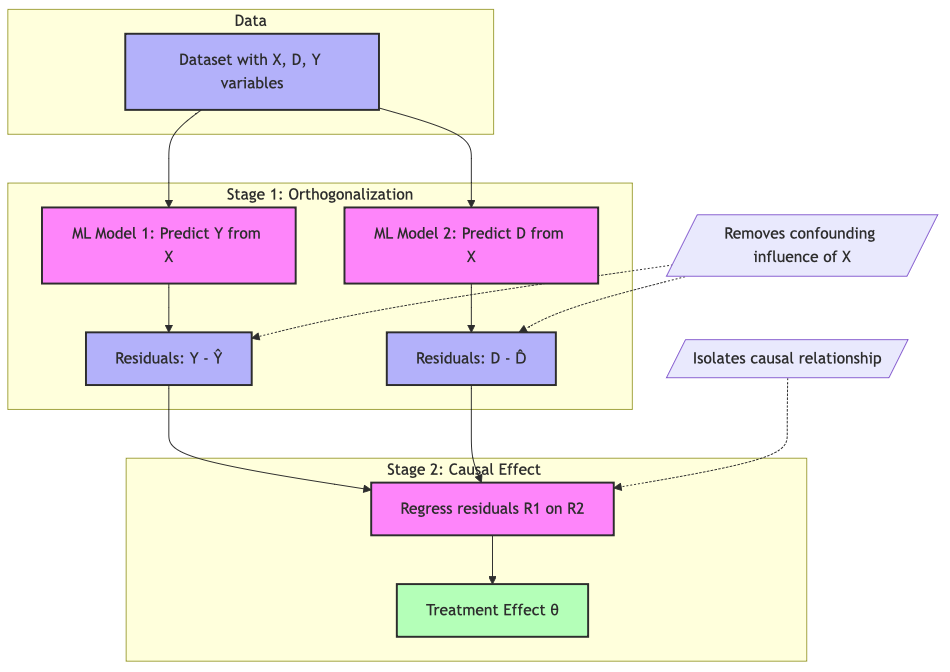

## Methods: Double Debiased Machine Learning I

- Traditional econometric approaches require trade-off
  - Including limited confounding information -> endogeneity concerns
  - Including a lot of controls -> modeling challenges due to complex functional forms (e.g., collinearity, non-linearity, etc.) (Belloni et al. 2017)
- Machine Learning can handle complex functional forms and data patterns
  - E.g., many non-linear controls, collinearity for predicting outcomes.
  - **But** delineating different factor’s distinct influence is challenging.
    - Estimates difficult to interpret due to (often) non-traceable data transformations.

## Methods: Double Debiased Machine Learning II

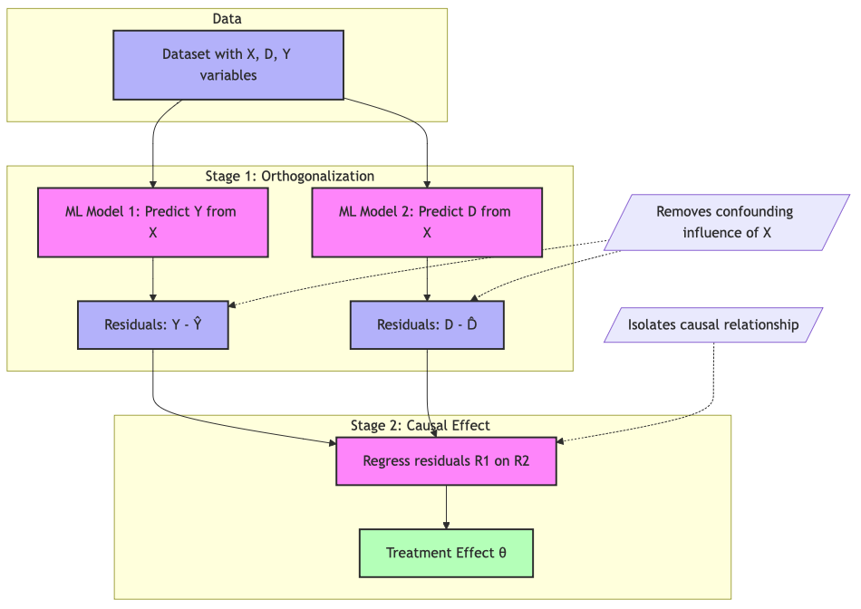

## Expected Contributions

### Empirical contribution

- First causal investigation into health income trade-off in context of protective measures during a pandemic
- Quantification of trade-off and comparison over time

### Theoretical Contribution

- Empirical test of widely-assumed trade-off assumption

### Policy relevance

- Informs more efficient data collections during early phases of emergencies
- Informs resource allocation efficiency

# Chapter II: The role of peer effects on vaccination intentions

RQ: What was the causal effect of peer groups on COVID-19 vaccination intentions in Ethiopia

## Background & Gaps

- Peer effect = effect of membership in group
- BUT: Self-selection into group raises question of mechanism of effects
  - Did my peers influence my decision
  - Or do my values, etc. drive my decision and I choose peers with similar values, etc
- Important implications for policy design: Target communication, etc better and save resources

## Data

### World Bank Ethiopia high frequency phone survey between 2020 and 2024

- Household panel data. Subset: 05/20-00/23
- Measures vaccine intentions
- Nationally representative sample of households
- Multiple respondents per household
- Survey experiment at R14: vaccine priming

## Methods

- Lagged outcome control design
  - **Explain vaccine intention based on previous intentions/vaccination status of household members**
- Exploit experimental manipulation at R14
  - Is the rate of vaccine intentions different between peers of respondents that received priming and those that did not

## Expected Contributions

### Empirical contribution

- First longitudinal analytical investigation of peer effects vs self-selection during COVID-19 in LMIC

### Theoretical Contribution

- Highlight role of peer effects vs self-selection in pandemic settings

### Policy relevance

- Inform better targeting of communication campaigns, etc

# Chapter III: Informing a theory of pandemic behavior

RQ: What are the direct and interacted effects of various behavioral determinants on compliance with public health measures

## Background & Gaps I

### Different factors interact and shape behavior **together**

- Some studies use theoretical frameworks (Health Belief Model `OR` Theory of Planned Behavior) to analyze survey data
- Only (Bui et al. 2023) in LMIC (Looking at students in Vietnam)
- No paper integrating/extending these in COVID-19 in LMIC
- No study comparing different geographical contexts
- No comparison of NPI and vaccines

## Frameworks

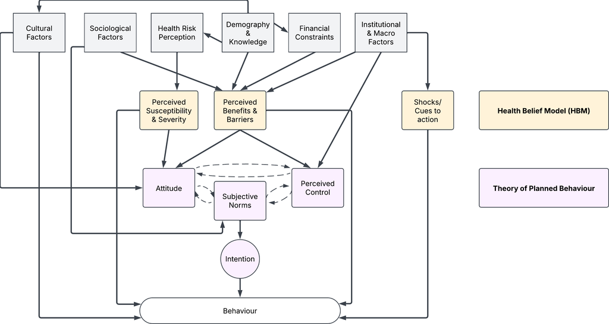

## Data

### MIT C19 preventative health survey

- Conducted via online surveys distributed to Facebook users globally
- Over 100k observations across 78 countries
- Weighted to account for probability of being FB user
- Contains data on all aforementioned factors
- Repeated cross-sectional survey
- Requested & granted. Currently correspondence between LSE Data Library and MIT

## Methods

- Structural equation modeling to uncover latent and observed pathways
  - Explicitly models causal pathways and feedback loops
  - Allows simultaneous estimation of direct and indirect effects in predicting preventive behavior
  - Conduct at different waves for robustness checks and comparison

## Methods

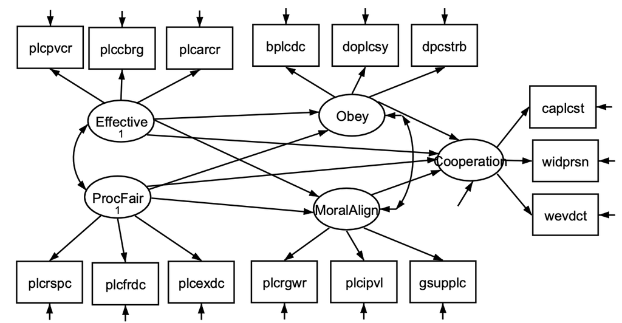

Example of a structural equation model

## Expected Contributions

### Empirical contribution

- First large scale SEM across countries and waves
- Quantification of uncertainty and relative importance of factors

### Theoretical Contribution

- Informing more comprehensive framework of pandemic behavior
- Introducing nuance around different intervention types (NPI vs vaccine)

### Policy relevance

- Informs more efficient data collections during early phases of emergencies
- Informs resource allocation efficiency

# Thank you

# Questions & Feedback

# Open questions

## Some things to consider

#### Health Income Trade-off

- Compare at different survey waves
- Measure Exposure variables as binary or continuous

#### Peer effects

- Focus on R14 (experiment) for more robust causal case
- Too many other dynamics within family (e.g. gender) to identify peer effects
- Can I elicit mechanisms of peer effects

#### Interactions of factors

- Compare countries Waves Outcomes
- Focus on one case Arbitrary

## Annex: Literature search strategy II: Search string

```python
TITLE-ABS-KEY(
  (pandemic* OR epidemic* OR outbreak* OR "public health crisis*")
  AND
  (behavio*r OR compliance OR adherence OR "preventiv* measures" OR "protective measures" OR mitigation OR "health response*"
    OR lockdown* OR "stay at home" OR "social distan*" OR quarantine OR "mask* use" OR "mask wearing" OR hygiene OR "hand wash*"
    OR "vaccine acceptance" OR "vaccination intent*" OR "testing uptake" OR "contact tracing" OR "physical distancing" OR "non-pharmaceutical intervention*")
)
AND
TITLE-ABS-KEY(
  (determinant* OR predictor* OR factor* OR driver* OR influenc*)
  AND
  (economic OR "socio-cultural" OR social OR institutional OR psychological OR "risk perception*" OR cognitive OR affective OR normative
    OR "peer effect*" OR "media influence*" OR politic* OR demographic* OR cultural OR structural OR contextual)
)
```

## Annex Gaps I

### Peer group effects vs self-selection

- Unclear whether group/network effects are driven by self-selection into groups
- Some descriptive insights from self-reported reasons for behavior
- Evidence from influenza suggests *pure* peer effects in vaccination behavior (Miyazato, Ibuka, and Itaya 2024)

## Annex Gaps II

### **Is** there a health vs income trade-off

- Trade-off widely assumed but never causally confirmed and quantified
  - Influence of economic status & health risk perception confirmed separately
  - Most studies on role of economic status done in HICs
  - Not yet modeled together and isolated from other factors that might *override* trade-off
  - Some WTP insights for vaccines (e.g. Catma and Varol 2021), but no quantification of impact of health risk perceptions **relative to economic vulnerability** and vice versa on NPI behavior

## Annex Gaps III

### Dynamic interactions

# Annex: Chapter I

## Annex: Structural Equation Modeling II (Skip)

### Confirmatory Factor Analysis (CFA)

- To validate latent constructs
- To operationalize constructs from survey items

### Comparative Model Evaluation

- Predictive power assessment (variance explained in preventative behavior)
- Multi-group SEM for cross-country/SES/gender comparisons
- Akaike Information Criterion (AIC) & Bayesian Information Criterion (BIC) for model comparison

# Annex II Chapter 2

## Annex: Chapter II BG: Malawi during waves 1 & 2 of C19

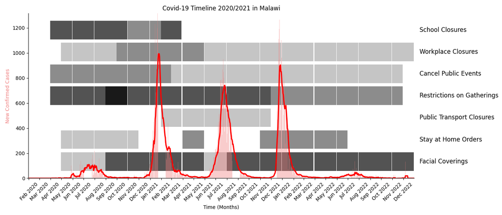

## Annex: Chapter II How: Outcomes

| `Outcome` | Indicators | Investigation at | Hypothesis tests |
| --- | --- | --- | --- |
| **`Social distancing`** | Gathering attendance; non-essential travels; Reduced Shopping | Multiple rounds | H1, H2, H3 |
| **`Hygiene & Mask`** | Hand Washing; Mask Wearing | Single Round | H2 |
| **`Willingness to test`*** | Willingness to test | Single Round | H1 |
| **`Vaccine Acceptance*`** | Willingness to vaccinate | Single round | H1 |

*Vaccines and tests are provided for free but involve significant transaction and opportunity costs. Reddy, K.P., Fitzmaurice, K.P., Scott, J.A. et al. Clinical outcomes and cost-effectiveness of COVID-19 vaccination in South Africa. Nat Commun 12, 6238 (2021)

## Annex: Chapter II How: Treatments I

### Economic Vulnerability Indicator

- Constructed from factors such as:
  - Current income
  - Self-reported economic stability perception
  - Economic risk perception due to the pandemic
  - Main income source (formal vs informal economy)
  - Consumption quantile (based on monthly spending)
- Operationalization methods under consideration:
  - Inverse Probability Weighting (IPW) by Anderson
  - Established economic vulnerability measures (e.g., Calvo & Dercon, 2005)
  - Data-driven approach (PCA or single factor analysis)

## Annex: Chapter II How: Treatments II

### Health Risk Perception Indicator

- Self-reported health risk perception
- Infection history and self-reported comorbidities
- Recent COVID-19 symptoms

### Trade-off as interaction term

## Annex: Chapter II How: Controlling for

- Demographics (Age, gender, education, urban/rural, etc)
- Cultural affiliations and beliefs (religion, parties, norms, etc)
- HH characteristics (size, adult equiv, etc)
- Exposure to C19
- Trust in institutions & conspiracy beliefs
- Mental health
- Macro context (policies, economic performance, etc)
- And some more (self-efficacy, C19 communication exposure, news consumption, etc)

## Annex: Chapter II How: Challenges of traditional econometric approaches I

[figure not shown]

## Annex: Chapter II How: Challenges of traditional econometric approaches II

### Strengths

- Interpretability
- Causal pathway identification

### Limitations

- Exogeneity concerns
  - Either RCT or
  - Quasi experimental approach difficult with income
  - Controlling requires many functional assumptions

## Annex: Chapter II How: Challenges of machine learning

### Strengths

- Very flexible re functional forms
- Can handle large amounts of covariates

### Limitations

- Overfitting concerns
- Causal pathway interpretation challenging

## Annex: Chapter II How: Double Debiased Machine Learning II

### Cross-fitting to reduce overfitting and regularization bias

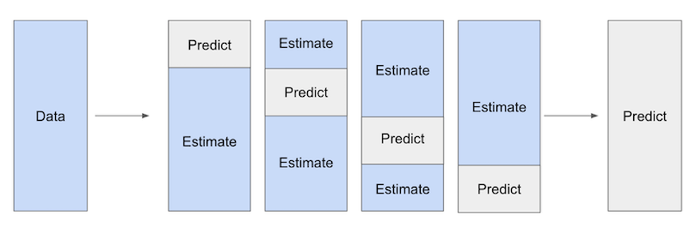

# Annex III Chapter 3

[figure not shown]

Alvarez-Galvez, J, A Anastasiou, D Lamnisos, M Constantinou, C Nicolaou, S Papacostas, VS Vasiliou, et al. 2023. “The Impact of Government Actions and Risk Perception on the Promotion of Self-Protective Behaviors During the COVID-19 Pandemic.” *PLOS ONE* 18 (4). https://doi.org/10.1371/journal.pone.0284433.

Badr, Hoda, Xiaotao Zhang, Abiodun Oluyomi, LeChauncy D. Woodard, Omolola E. Adepoju, Syed Ahsan Raza, and Christopher I. Amos. 2021. “Overcoming COVID-19 Vaccine Hesitancy: Insights from an Online Population-Based Survey in the United States.” *Vaccines* 9 (10): 1100. https://doi.org/10.3390/vaccines9101100.

Bazrafshan, A, A Sadeghi, MS Bazrafshan, H Mirzaie, M Shafiee, J Geerts, and H Sharifi. 2023. “Health Risk Communication and Infodemic Management in Iran: Development and Validation of a Conceptual Framework.” *BMJ OPEN* 13 (7). https://doi.org/10.1136/bmjopen-2023-072326.

Belloni, A., V. Chernozhukov, I. Fern�ndez-Val, and C. Hansen. 2017. “Program Evaluation and Causal Inference With High-Dimensional Data.” *Econometrica* 85 (1): 233–98. https://doi.org/10.3982/ECTA12723.

Bui, Huy Nhuong, Cong Doanh Duong, Van Quang Nguyen, Ngoc Xuan Vu, Son Tung Ha, Trung Thanh Le, and Trong Nghia Vu. 2023. “Utilizing the Theory of Planned Behavior to Predict COVID-19 Vaccination Intention: A Structural Equational Modeling Approach.” *Heliyon* 9 (6): e17418. https://doi.org/10.1016/j.heliyon.2023.e17418.

Catma, Serkan, and Serkan Varol. 2021. “Willingness to Pay for a Hypothetical COVID-19 Vaccine in the United States: A Contingent Valuation Approach.” *Vaccines* 9 (4): 318. https://doi.org/10.3390/vaccines9040318.

Erman, Aysegul, and Mike Medeiros. 2021. “Exploring the Effect of Collective Cultural Attributes on Covid-19-Related Public Health Outcomes.” *Frontiers in Psychology* 12 (March): 627669. https://doi.org/10.3389/fpsyg.2021.627669.

Ferreira Caceres, Maria Mercedes, Juan Pablo Sosa, Jannel A Lawrence, Cristina Sestacovschi, Atiyah Tidd-Johnson, Muhammad Haseeb UI Rasool, Vinay Kumar Gadamidi, et al. 2022. “The Impact of Misinformation on the COVID-19 Pandemic.” *AIMS Public Health* 9 (2): 262–77. https://doi.org/10.3934/publichealth.2022018.

Filsinger, M, and M Freitag. 2024. “Asymmetric Affective Polarization Regarding COVID-19 Vaccination in Six European Countries.” *SCIENTIFIC REPORTS* 14 (1). https://doi.org/10.1038/s41598-024-66756-w.

Gelfand, Michele J, Joshua Conrad Jackson, Xinyue Pan, Dana Nau, Dylan Pieper, Emmy Denison, Munqith Dagher, Paul A M Van Lange, Chi-Yue Chiu, and Mo Wang. 2021. “The Relationship Between Cultural Tightness–Looseness and COVID-19 Cases and Deaths: A Global Analysis.” *The Lancet. Planetary Health* 5 (3): e135–44. https://doi.org/10.1016/S2542-5196(20)30301-6.

Govind, R, N Garg, and L Carter. 2024. “Selling Hope Versus Hate: The Impact of Partisan Social Media Messaging on Social Distancing During the COVID-19 Pandemic.” *EUROPEAN JOURNAL OF MARKETING* 58 (2): 632–58. https://doi.org/10.1108/EJM-12-2022-0911.

Grossman, Michael. 1972. “On the Concept of Health Capital and the Demand for Health.” *Journal of Political Economy* 80 (2): 223–55. https://www.jstor.org/stable/1830580.

Guimaraes, RM, JHCM da Silva, GPD Brusse, and TCD Martins. 2021. “Effect of Physical Distancing on Covid-19 Incidence in Brazil: Does the Strictness of Mandatory Rules Matter?” *HEALTH POLICY AND PLANNING* 36 (10): 1605–12. https://doi.org/10.1093/heapol/czab110.

He, YP, H Yatsuya, A Ota, and T Tabuchi. 2022. “The Association of Public Trust with the Utilization of Digital Contact Tracing for COVID-19 in Japan.” *PUBLIC HEALTH IN PRACTICE* 4 (December). https://doi.org/10.1016/j.puhip.2022.100279.

Keshet, Y. 2020. “Fear of Panoptic Surveillance: Using Digital Technology to Control the COVID-19 Epidemic.” *ISRAEL JOURNAL OF HEALTH POLICY RESEARCH* 9 (1). https://doi.org/10.1186/s13584-020-00429-7.

Makridis, Christos A., and Cary Wu. 2021. “How Social Capital Helps Communities Weather the COVID-19 Pandemic.” *PLOS ONE* 16 (1): e0245135. https://doi.org/10.1371/journal.pone.0245135.

Miftode, RS, II Costache, P Cianga, AO Petris, CM Cianga, MA Maranduca, IL Miftode, et al. 2021. “The Influence of Socioeconomic Status on the Prognosis and Profile of Patients Admitted for Acute Heart Failure During COVID-19 Pandemic: Overestimated Aspects or a Multifaceted Hydra of Cardiovascular Risk Factors?” *HEALTHCARE* 9 (12). https://doi.org/10.3390/healthcare9121700.

Miyazato, Naomi, Yoko Ibuka, and Jun-ichi Itaya. 2024. “Peer Effects on Influenza Vaccination: Evidence from a City’s Administrative Data in Japan.” *Journal of the Japanese and International Economies* 74 (December): 101335. https://doi.org/10.1016/j.jjie.2024.101335.

Mohammed, E, S Khanal, Z Jalal, E Cheema, MH Abutaleb, and V Paudyal. 2021. “Perceived Barriers and Facilitators to Uptake of Non-Traditional Roles by Pharmacists in Saudi Arabia and Implications for COVID-19 Pandemic and Beyond: A Qualitative Study Using Theoretical Domain Framework.” *JOURNAL OF PHARMACEUTICAL POLICY AND PRACTICE* 14 (1). https://doi.org/10.1186/s40545-021-00307-w.

Nair, Nisha, Patturaja Selvaraj, and Ranjeet Nambudiri. 2022. “Culture and COVID-19: Impact of Cross-Cultural Dimensions on Behavioral Responses.” *Encyclopedia* 2 (3): 1210–24. https://doi.org/10.3390/encyclopedia2030081.

Neville, Fergus G., Anne Templeton, Joanne R. Smith, and Winnifred R. Louis. 2021. “Social Norms, Social Identities and the COVID-19 Pandemic: Theory and Recommendations.” *Social and Personality Psychology Compass* 15 (5): e12596. https://doi.org/10.1111/spc3.12596.

Saville, Christopher W. N., Robin Mann, Anthony Scott Lockard, Aidan Bark-Connell, Stella Gmekpebi Gabuljah, April M. Young, and Daniel Rhys Thomas. 2024. “Covid and the Common Good: In-group Out-Group Dynamics and Covid-19 Vaccination in Wales and the United States.” *Social Science & Medicine* 352 (July): 117022. https://doi.org/10.1016/j.socscimed.2024.117022.

Stevens, AJ, AM Ray, A Thirunavukarasu, E Johnson, L Jones, A Miller, and JWT Elston. 2021. “The Experiences of Socially Vulnerable Groups in England During the COVID-19 Pandemic: A Rapid Health Needs Assessment.” *PUBLIC HEALTH IN PRACTICE* 2 (November). https://doi.org/10.1016/j.puhip.2021.100192.

Wollast, Robin, Mathias Schmitz, Alix Bigot, and Olivier Luminet. 2021. “The Theory of Planned Behavior During the COVID-19 Pandemic: A Comparison of Health Behaviors Between Belgian and French Residents.” *PLoS ONE* 16 (11): e0258320. https://doi.org/10.1371/journal.pone.0258320.

Xiong, YF, CT Wang, and Y Zhang. 2024. “Interacting Particle Models on the Impact of Spatially Heterogeneous Human Behavioral Factors on Dynamics of Infectious Diseases.” *PLOS COMPUTATIONAL BIOLOGY* 20 (8). https://doi.org/10.1371/journal.pcbi.1012345.

Zu, J, MW Shen, CK Fairley, ML Li, GQ Li, LB Rong, YN Xiao, GH Zhuang, L Zhang, and Y Li. 2021. “Investigating the Relationship Between Reopening the Economy and Implementing Control Measures During the COVID-19 Pandemic.” *PUBLIC HEALTH* 200 (November): 15–21. https://doi.org/10.1016/j.puhe.2021.09.005.

Zucoloto, ML, AC Meneghini, and EZ Martinez. 2022. “Panorama of COVID-19, Risk Perception and Vaccine Confidence in Sao Paulo State Population, Southeast Brazil.” *HEALTH & SOCIAL CARE IN THE COMMUNITY* 30 (6): E4662–72. https://doi.org/10.1111/hsc.13872.